# Casual Inference Notebook

In this assignment we will exercise causal inference on the RHC (Right Heart Catheterization) dataset This dataset was used in Connors et al. (1996): The effectiveness of RHC in the initial care of critically ill patients. J American Medical Association 276:889-897. The dataset pertains to day 1 of hospitalization, i.e., the “treatment” variable swang1 is whether or not a patient received a RHC (also called the Swan-Ganz catheter) on the first day in which the patient qualified for a specific research study called SUPPORT.

What should you submit? You need to submit: 1. This Notebook (in .Rmd format) after filling in all your answers inside this notebook. You are required to do an action (write or fill-in code or write documentation) at the places marked by an arrow (=>). This arrow appears within the comments (and it will be preceeded by “#”) or outside the comments in the text (without “#”). 2. The Notebook in html format with all the results.

==> Student names: Elena Deiana, Ramon Cremers ==> Student numbers: 14110822, 14090945 # Open part

## Understand the datase:

Please Open https://hbiostat.org/data/repo/rhc.html and take a good look at the variables. Make sure you inspect the variables included in the dataset (they appear in a table below the text on the website). You can refer to the table whenever needed.

Packages: install packages if needed

```r
# install.packages("tableone")
# install.packages("Matching")
# install.packages("tidyverse") #added
# install.packages('rlang')     #added
# install.packages('Metrics')   #added
# install.packages('ggplot2')   #added

# Recommended: add "dplyr" if you have used it before to make efficient preprocessing.
```

## Load packages

```r
library(tableone) # This library allows us to calculate summary statistics about the variables including the SMD (standardized mean difference).
library(Matching) # This library will do the matching
library('dplyr')  #added
library(Metrics)  #added
library(ggplot2)  #added
```

## Read database

```r
# Download rhc dataset from CANVAS and read it
rhc <- read.csv("rhc.csv")
set.seed(14)
```

## Understanding the dataset

Tip: Look at the data, use the “View” command on the dataset “rhc”

```r
print("===================================================")
```

```
[1] "==================================================="
```

```r
# => how many rows does rhc contain?
nr <- nrow(rhc)   #5735 rows
sprintf('The dataset contains %s rows', nr)
```

```
[1] "The dataset contains 5735 rows"
```

```r
# => What are the variable names?
nc <- ncol(rhc)    #74 column
sprintf('The %s variable names are the following below:', nc)
```

```
[1] "The 63 variable names are the following below:"
```

```r
names(rhc)
```

```
 [1] "X"        "cat1"     "cat2"     "ca"       "sadmdte"  "dschdte"  "dthdte"   "lstctdte" "death"    "cardiohx"
[11] "chfhx"    "dementhx" "psychhx"  "chrpulhx" "renalhx"  "liverhx"  "gibledhx" "malighx"  "immunhx"  "transhx"
[21] "amihx"    "age"      "sex"      "edu"      "surv2md1" "das2d3pc" "t3d30"    "dth30"    "aps1"     "scoma1"
[31] "meanbp1"  "wblc1"    "hrt1"     "resp1"    "temp1"    "pafi1"    "alb1"     "hema1"    "bili1"    "crea1"
[41] "sod1"     "pot1"     "paco21"   "ph1"      "swang1"   "wtkilo1"  "dnr1"     "ninsclas" "resp"     "card"
[51] "neuro"    "gastr"    "renal"    "meta"     "hema"     "seps"     "trauma"   "ortho"    "adld3p"   "urin1"
[61] "race"     "income"   "ptid"
```

```r
print("===================================================")
```

```
[1] "==================================================="
```

For the assignment the TREATMENT variable is swang1 and the OUTCOME variable is death.

## Preprocess

If you look at the values of the dichotomous variables you will see that they are factors (in other words, categorical variables). We would like to work with numeric variables in this exercise so we need to perform some conversions.

Let’s start with the treatment and outcome variables. Create an “outcome.died” and “swang.treatment” variables with the numeric values 0 and 1.

```r
rhc$outcome.died <- as.numeric(rhc$death=='Yes')  # Again you might want, instead, to do all preprocessing with dplyr if you prefer
rhc$treatment.swang <- as.numeric(rhc$swang1=='RHC')
```

### Check

Let’s take a quick look into the dataset using these variables

```r
print("===================================================")
```

```
[1] "==================================================="
```

```r
# => What is the mean of outcome.died in the whole data set?
m1 <- mean(rhc$outcome.died)
sprintf('The mean of outcome.died: %s', m1)
```

```
[1] "The mean of outcome.died: 0.648997384481255"
```

```r
# => How many subjects are treated?
s1 <- sum(rhc$swang1=='RHC')
sprintf('The number of treated subjects: %s', s1)
```

```
[1] "The number of treated subjects: 2184"
```

```r
# =>  What is the mean mortality (outcome.died) in this treated group?
m2 <- mean(rhc$swang1=='RHC' & rhc$outcome.died == 1)
sprintf('The mean mortality of treated group: %s ', m2)
```

[output not shown]

```r
# => How many subjects are not treated (i.e. in the control group)?
s3 <- sum(rhc$swang1=='No RHC')
sprintf('The number of not treated subjects: %s', s3)
```

```
[1] "The number of not treated subjects: 3551"
```

```r
# => What is the mean mortality in this control group?
m3 <- mean(rhc$swang1=='No RHC' & rhc$outcome.died == 1)
sprintf('Mean mortality for not treated: %s', m3)
```

[output not shown]

```r
print("===================================================")
```

```
[1] "==================================================="
```

The variable cat1 is a factor (categorical variable) containing the primary disease category for the patient.

```r
print("===================================================")
```

```
[1] "==================================================="
```

```r
# => How many different categories are in Cat1? Tip: use the levels() function on this variable.
rhc$cat1 <- as.factor(rhc$cat1)  #from chr (character) to factor
ncat <- nlevels(rhc$cat1)
sprintf("The number of categories in 'cat1' is %s.", ncat)
```

```
[1] "The number of categories in 'cat1' is 9."
```

```r
print("===================================================")
```

```
[1] "==================================================="
```

We would like to “translate” Cat1 into a set of variables each with the numeric values of 0/1. For example for the value of “ARF” we will create a variable “ARF” that will be 1 if rhc$cat1==‘ARF’.

```r
rhc$ARF <- as.numeric(rhc$cat1=='ARF')
print("===================================================")
```

```
[1] "==================================================="
```

```r
# => Do the same (as we did for ARF) also for all other values of cat1 but ignore the category "Missing".
cat1_list <- list(levels(rhc$cat1))
print(cat1_list)
```

```
[[1]]
[1] "ARF"               "CHF"               "Cirrhosis"         "Colon Cancer"      "Coma"
[6] "COPD"              "Lung Cancer"       "MOSF w/Malignancy" "MOSF w/Sepsis"
```

```r
rhc$CHF <- as.numeric(rhc$cat1=='CHF')
rhc$Cirrhosis <- as.numeric(rhc$cat1=='Cirrhosis')
rhc$Colon_Cancer <- as.numeric(rhc$cat1=='Colon Cancer')
rhc$Coma <- as.numeric(rhc$cat1=='Coma')
rhc$COPD <- as.numeric(rhc$cat1=='COPD')
rhc$Lung_Cancer <- as.numeric(rhc$cat1=='Lung Cancer')
rhc$MOSF_Malignancy <- as.numeric(rhc$cat1=='MOSF w/Malignancy')
rhc$MOSF_Sepsis <- as.numeric(rhc$cat1=='MOSF w/Sepsis')

print("===================================================")
```

```
[1] "==================================================="
```

## Create data frame with variables of interest

==> Create a data frame and call it rhc.small with the following variables of interest: All the underlying categories of “cat1” (ARF etc) that you created before, “cardiohx”, “chfhx”, “dementhx”, “psychhx”, “chrpulhx”, “renalhx”, “liverhx”, “gibledhx”, “malighx”, “immunhx”, “transhx”, “amihx”, “age”,  
“female”, “edu”, “das2d3pc”, “aps1”, “scoma1”, “meanbp1”, wblc1”, “hrt1”, “resp1”, “temp1”, “pafi1”, “alb1”, “hema1”, “bili1”, “crea1”, “sod1”, “pot1”, “paco21”, “ph1”, “wtkilo1”, “dnr1”, “resp”, “card”, “neuro”, “gastr”, “renal”, “meta”, “hema”, “seps”, “trauma”, “ortho”, “adld3p”, “urin1”, “treatment.swang”, “outcome.died”.

```r
print("===================================================")
```

```
[1] "==================================================="
```

```r
print("We already added the 'female' column here instead of later. This way we did not have to alter the original rhc data and also did not have to import the 'sex' column into 'rhc.small'.")
```

```
[1] "We already added the 'female' column here instead of later. This way we did not have to alter the original rhc data and also did not have to import the 'sex' column into 'rhc.small'."
```

```r
rhc.small <- rhc
rhc.small$female <- as.numeric(rhc.small$sex=='Female')
rhc.small <- rhc.small[,c("ARF", "CHF", "Cirrhosis", "Colon_Cancer", "Coma", "COPD", "Lung_Cancer", "MOSF_Malignancy", "MOSF_Sepsis", "cardiohx", "chfhx", "dementhx", "psychhx",  "chrpulhx", "renalhx", "liverhx",  "gibledhx", "malighx",  "immunhx",  "transhx",  "amihx", "age", "female", "edu", "das2d3pc", "aps1", "scoma1", "meanbp1", "wblc1", "hrt1", "resp1", "temp1", "pafi1", "alb1", "hema1", "bili1", "crea1", "sod1", "pot1",     "paco21", "ph1", "wtkilo1", "dnr1", "resp", "card", "neuro", "gastr",  "renal", "meta", "hema", "seps", "trauma",  "ortho", "adld3p", "urin1", "treatment.swang", "outcome.died")]
print("===================================================")
```

```
[1] "==================================================="
```

Make sure you take a look at the definition of variables (on the URL given above) with unclear names to you. This data frame includes now all candidate variables from which we will select later for matching. However, before we jump into variable selection let us continue data class conversion.

Check classes of these variables by using the str command

```r
str(rhc.small)   #to check classes of all variables
```

```
'data.frame':   5735 obs. of  57 variables:
 $ ARF            : num  0 0 0 1 0 0 0 1 0 1 ...
 $ CHF            : num  0 0 0 0 0 0 0 0 0 0 ...
 $ Cirrhosis      : num  0 0 0 0 0 0 0 0 0 0 ...
 $ Colon_Cancer   : num  0 0 0 0 0 0 0 0 0 0 ...
 $ Coma           : num  0 0 0 0 0 0 0 0 0 0 ...
 $ COPD           : num  1 0 0 0 0 1 0 0 0 0 ...
 $ Lung_Cancer    : num  0 0 0 0 0 0 0 0 0 0 ...
 $ MOSF_Malignancy: num  0 0 1 0 0 0 1 0 1 0 ...
 $ MOSF_Sepsis    : num  0 1 0 0 1 0 0 0 0 0 ...
 $ cardiohx       : int  0 1 0 0 0 0 0 0 0 0 ...
 $ chfhx          : int  0 1 0 0 0 1 0 0 0 0 ...
 $ dementhx       : int  0 0 0 0 0 0 0 0 0 0 ...
 $ psychhx        : int  0 0 0 0 0 0 0 0 0 0 ...
 $ chrpulhx       : int  1 0 0 0 0 1 0 0 0 0 ...
```

[output cut: 43 more lines]

If you have “labelled” variables like labelled int and labelled num it means that the datset was imported from SPSS. In such case change such variables into numeric variables. If you do not see such variables then skip this step.

```r
#rhc.small$age <- as.numeric(rhc.small$age) # only if in your version of the data "age" was a "labelled" variable
print("===================================================")
```

```
[1] "==================================================="
```

```r
# => Change all labelled variables that include numbers (integer or numeric) into numeric.
print("We have not labelled variables, so we can skip this step.")
```

```
[1] "We have not labelled variables, so we can skip this step."
```

```r
print("===================================================")
```

```
[1] "==================================================="
```

For each categorical variable with 2 values (such as sex) change it into a numeric variable by selecting one of the values value (such as “female”) to be 1 and the other zero.

```r
## rhc.small$female <- as.numeric(rhc.small$sex=='Female')
print("===================================================")
```

```
[1] "==================================================="
```

```r
print("We already created the female column earlier because we were required to put it into rhc.small")
```

```
[1] "We already created the female column earlier because we were required to put it into rhc.small"
```

```r
#rhc.small$resp<-ifelse(df1$resp=="Yes",1,0)
rhc.small$resp <- as.numeric(rhc.small$resp=='Yes')
rhc.small$card <- as.numeric(rhc.small$card=='Yes')
rhc.small$gastr <- as.numeric(rhc.small$gastr=='Yes')
rhc.small$renal <- as.numeric(rhc.small$renal=='Yes')
rhc.small$hema <- as.numeric(rhc.small$hema=='Yes')
rhc.small$seps <- as.numeric(rhc.small$seps=='Yes')
rhc.small$trauma <- as.numeric(rhc.small$trauma=='Yes')
rhc.small$neuro <- as.numeric(rhc.small$neuro=='Yes')
rhc.small$meta <- as.numeric(rhc.small$meta=='Yes')
rhc.small$ortho <- as.numeric(rhc.small$ortho=='Yes')
rhc.small$dnr1 <- as.numeric(rhc.small$dnr1=='Yes')

# => Change any factor with two values into a 0/1 variable by selecting a value (such as "female" above) to be 1 and the other value will be zero.
print("===================================================")
```

```
[1] "==================================================="
```

Before we start the analysis we need to be aware of the following issue: If you encounter a variable with missing values then you might run into a problem with the Match() function later on. For this exercise you can follow this advice:

1. If the proportion of missing is above 15% then just exclude the whole variable from the data frame and hence from the analysis, it is likely that the information it had still resides in the combination of the many other variables.
2. If you have less than 15% missing variables try to impute the values of the variable. In the extreme case you could apply multiple imputations and repeat the analysis on each imputation set and then pool the results. However for this exercise you can follow a simple strategy such as imputing the value with mean/median/mode. This would be a limitation but imputing missing values is not the focus of our exercise on causal inference.

=> Inspect the proportion of missing values for each variable and follow the advice above.

```r
print("===================================================")
```

```
[1] "==================================================="
```

```r
missing <- colMeans(is.na(rhc.small))*100 ##check percentage of NA per column
print(missing)
```

```
            ARF             CHF       Cirrhosis    Colon_Cancer            Coma            COPD     Lung_Cancer
        0.00000         0.00000         0.00000         0.00000         0.00000         0.00000         0.00000
MOSF_Malignancy     MOSF_Sepsis        cardiohx           chfhx        dementhx         psychhx        chrpulhx
        0.00000         0.00000         0.00000         0.00000         0.00000         0.00000         0.00000
        renalhx         liverhx        gibledhx         malighx         immunhx         transhx           amihx
        0.00000         0.00000         0.00000         0.00000         0.00000         0.00000         0.00000
            age          female             edu        das2d3pc            aps1          scoma1         meanbp1
        0.00000         0.00000         0.00000         0.00000         0.00000         0.00000         0.00000
          wblc1            hrt1           resp1           temp1           pafi1            alb1           hema1
        0.00000         0.00000         0.00000         0.00000         0.00000         0.00000         0.00000
          bili1           crea1            sod1            pot1          paco21             ph1         wtkilo1
        0.00000         0.00000         0.00000         0.00000         0.00000         0.00000         0.00000
           dnr1            resp            card           neuro           gastr           renal            meta
        0.00000         0.00000         0.00000         0.00000         0.00000         0.00000         0.00000
           hema            seps          trauma           ortho          adld3p           urin1 treatment.swang
        0.00000         0.00000         0.00000         0.00000        74.90846        52.79861         0.00000
   outcome.died
        0.00000
```

```r
exclude <- vector(mode = "list", length = 0)
for(colname in names(missing)){
  if(missing[[colname]] > 15){ ## if more than 15% of data is missing:
    cat(missing[[colname]], colname, '\n')
    exclude <- append(exclude, colname) ## contains "adld3p" and "urin1"
  }
}
```

```
74.90846 adld3p
52.79861 urin1
```

```r
print('Columns to be removed:')
```

```
[1] "Columns to be removed:"
```

```r
print(exclude)
```

```
[[1]]
[1] "adld3p"

[[2]]
[1] "urin1"
```

```r
rhc.small <- rhc.small[, !colnames(rhc.small) %in% exclude]

print("There are no other columns which have any NA's, so step 2 about imputing doesn't apply")
```

```
[1] "There are no other columns which have any NA's, so step 2 about imputing doesn't apply"
```

```r
print("===================================================")
```

```
[1] "==================================================="
```

Now we are ready to start the analysis.

## Selecting variables to control for

According to the disjunctive cause criterion we want to find variables (to control for) that are predictive of treatment and/or the outcome. In this assignment we will use the criterion to select all (pre-treatment) variables that are predictive of the outcome. This will include true confounders (that also affect the treatment, and risk factors that only affect the outcome). All our variables in rhc.small, except the outcome of course, are pre-treatment variables (none is measured AFTER the intervention) so they are all good candidates for the selection.

The truth is that the best way to select these variables is to use clinical knowledge. However, in this assignment we will do this in a data-driven and practical way. Specifically, we will operationalize “predictive of the outcome” as the following criterion: a variable is predictive of the outcome if its univariate association with the outcome is significant at the 0.1 level. Because our outcome is binary we can translate this criterion to: For every candidate variable in rhc.small fit a logistic regression model to predict outcome (outcome.died) using only the candidate variable as a predictor and retain the variable if the p-value of its association with the outcome is ≤ 0.1, and otherwise discard the variable. Note: Do not include the treatment in the selection.

```r
print("===================================================")
```

```
[1] "==================================================="
```

```r
# => Fit logistic regression models for each variable separately with the outcome and retain those with an association having a p-value of ≤ 0.1. Tip: you may want to automate the whole process!
xvars <- vector(mode = "list", length = 0)

for(i in seq_along(rhc.small)){
  if(names(rhc.small[i]) == 'treatment.swang' || names(rhc.small[i]) == 'outcome.died'){
    next
  }
  mod <- as.formula(sprintf("outcome.died ~ %s", names(rhc.small[i])))
  model <- glm(formula = mod, family = binomial, data = rhc.small)
  pValue <- coef(summary(model))[,'Pr(>|z|)']
  pValue <- pValue[2]
  if(pValue <= 0.1){
    xvars <- append(xvars, names(rhc.small[i]))
  }
}

# => Put the names of the selected variables (without the treatment and outcome variables) in the variable xvars by writing xvars <- c("ARF", ...) or do it automatically as described in the tip.

# => Put these selected variables in a data.frame called 'rhc.selected' that also includes the treatment and outcome variables to this data frame.
idx <- match(xvars, names(rhc.small))
rhc.selected <- rhc.small[,idx]
rhc.selected$treatment.swang <- rhc.small$treatment.swang   #adding treatment variables
rhc.selected$outcome.died <- rhc.small$outcome.died         #adding outcome variables
print("===================================================")
```

```
[1] "==================================================="
```

## Inspect balance before matching

## look at “table 1”

```r
xvars <- unlist(xvars)  #to convert it into a vector instead of a list
```

```r
print("===================================================")
```

```
[1] "==================================================="
```

```r
#=> look at "table 1", complete the command by filling in the "..."

table1<- CreateTableOne(vars=xvars, strata='treatment.swang', data=rhc.selected, test=FALSE)
## include standardized mean difference (SMD)
#print(table1, smd=TRUE)
## For which variables we do not have a good balance? Look at the slides for a guideline.

print("As mentioned in slide 102, variables that have a serious imbalance are the ones with SMD > 0.2")
```

```
[1] "As mentioned in slide 102, variables that have a serious imbalance are the ones with SMD > 0.2"
```

```r
addmargins(table(ExtractSmd(table1) > 0.2)) #counting number of variables with SMD > 0.2 (=12)
```

```
FALSE  TRUE   Sum
   28    12    40
```

```r
#creating a dataframe to extract those variables

df_smd <- data.frame(variable = rownames(ExtractSmd(table1)),
                    Unmatched = as.numeric(ExtractSmd(table1)))
print('12 variables have smd > 0.2:')
```

```
[1] "12 variables have smd > 0.2:"
```

```r
df_smd$variable[df_smd$Unmatched>0.2]
```

```
 [1] "Coma"    "aps1"    "meanbp1" "alb1"    "hema1"   "crea1"   "paco21"  "wtkilo1" "dnr1"    "resp"    "card"
[12] "seps"
```

```r
print("===================================================")
```

```
[1] "==================================================="
```

## Greedy matching on Mahalanobis distance

Let us now do matching in the hope that the balance will get better so we can have a more valid inference.

```r
print("===================================================")
```

```
[1] "==================================================="
```

```r
# We want to match the treated with the untreated subjects. Find 1 on 1 match.
# # => Complete the command
treatment <- as.numeric(rhc.selected$treatment.swang==1)
greedymatch <- Match(Tr=treatment, M=1,X=rhc.selected[xvars], replace=FALSE)

# read the documentation for Match() by typing ?Match.
# => What does replace=FALSE mean?
print(" 'replace=FALSE' means that the order of matches matters as they will be founded in the same way the data are ordered so this introduces more bias.")
```

```
[1] " 'replace=FALSE' means that the order of matches matters as they will be founded in the same way the data are ordered so this introduces more bias."
```

```r
# => What is inside X?
print('Inside X there is the matrix containing the variables we wish to match on.')
```

```
[1] "Inside X there is the matrix containing the variables we wish to match on."
```

```r
rhc.selected[xvars]
```

| ARF | CHF | Cirrhosis | Coma | Lung_Cancer | MOSF_Malignancy | cardiohx | chfhx | dementhx | psychhx | chrpulhx | renalhx | liverhx | malighx | immunhx | transhx | age | edu | das2d3pc | aps1 | scoma1 | meanbp1 | wblc1 | temp1 | alb1 | hema1 | bili1 | crea1 | pot1 | paco21 | … |
| --- | --- | --- | --- | --- | --- | --- | --- | --- | --- | --- | --- | --- | --- | --- | --- | --- | --- | --- | --- | --- | --- | --- | --- | --- | --- | --- | --- | --- | --- | --- |
| 0 | 0 | 0 | 0 | 0 | 0 | 0 | 0 | 0 | 0 | 1 | 0 | 0 | 1 | 0 | 0 | 70.25098 | 12.000000 | 23.50000 | 46 | 0 | 41 | 22.09765620 | 38.69531 | 3.5000000 | 58.00000 | 1.00976562 | 1.19995117 | 4.000000 | 40.00000 | … |
| 0 | 0 | 0 | 0 | 0 | 0 | 1 | 1 | 0 | 0 | 0 | 0 | 0 | 0 | 1 | 1 | 78.17896 | 12.000000 | 14.75195 | 50 | 0 | 63 | 28.89843750 | 38.89844 | 2.5996094 | 32.50000 | 0.69995117 | 0.59997559 | 3.299805 | 34.00000 | … |
| 0 | 0 | 0 | 0 | 0 | 1 | 0 | 0 | 0 | 0 | 0 | 0 | 0 | 1 | 1 | 0 | 46.09198 | 14.069916 | 18.13672 | 82 | 0 | 57 | 0.04999542 | 36.39844 | 3.5000000 | 21.09766 | 1.00976562 | 2.59960938 | 2.899902 | 16.00000 | … |
| 1 | 0 | 0 | 0 | 0 | 0 | 0 | 0 | 0 | 0 | 0 | 0 | 0 | 0 | 1 | 0 | 75.33197 | 9.000000 | 22.92969 | 48 | 0 | 55 | 23.29687500 | 35.79688 | 3.5000000 | 26.29688 | 0.39996338 | 1.69995117 | 5.799805 | 30.00000 | … |
| 0 | 0 | 0 | 0 | 0 | 0 | 0 | 0 | 0 | 0 | 0 | 0 | 0 | 0 | 0 | 0 | 67.90997 | 9.945259 | 21.05078 | 72 | 41 | 65 | 29.69921880 | 34.79688 | 3.5000000 | 24.00000 | 1.00976562 | 3.59960938 | 5.799805 | 17.00000 | … |
| 0 | 0 | 0 | 0 | 0 | 0 | 0 | 1 | 0 | 0 | 1 | 0 | 0 | 0 | 0 | 0 | 86.07794 | 8.000000 | 17.50000 | 38 | 0 | 115 | 18.00000000 | 39.19531 | 3.0996094 | 30.50000 | 1.00976562 | 1.39990234 | 5.399414 | 68.00000 | … |
| 0 | 0 | 0 | 0 | 0 | 1 | 0 | 0 | 0 | 0 | 0 | 0 | 0 | 1 | 0 | 0 | 54.96799 | 14.000000 | 15.40625 | 29 | 26 | 67 | 7.69921875 | 39.39844 | 3.5000000 | 29.00000 | 1.00976562 | 1.00000000 | 3.699707 | 45.00000 | … |
| 1 | 0 | 0 | 0 | 0 | 0 | 0 | 0 | 0 | 0 | 0 | 0 | 0 | 0 | 0 | 1 | 43.63898 | 12.000000 | 29.14453 | 25 | 100 | 128 | 38.09375000 | 39.19531 | 2.6997070 | 33.59375 | 0.89990234 | 0.69995117 | 4.099609 | 26.00000 | … |
| 0 | 0 | 0 | 0 | 0 | 1 | 0 | 0 | 0 | 0 | 0 | 0 | 0 | 0 | 0 | 0 | 18.04199 | 12.821571 | 26.28906 | 47 | 0 | 53 | 2.00000000 | 38.39844 | 3.0000000 | 18.89844 | 1.09985352 | 1.69995117 | 3.099609 | 40.00000 | … |
| 1 | 0 | 0 | 0 | 0 | 0 | 0 | 0 | 0 | 0 | 0 | 0 | 0 | 1 | 0 | 0 | 48.42398 | 11.040535 | 23.25781 | 48 | 0 | 73 | 20.59765620 | 38.50000 | 2.5000000 | 32.69531 | 0.50000000 | 0.50000000 | 3.099609 | 30.00000 | … |

[output cut: 990 more lines]

```r
print("===================================================")
```

```
[1] "==================================================="
```

```r
?Match #useful to read the documentation for Match()
```

```r
print("===================================================")
```

```
[1] "==================================================="
```

```r
greedymatch$index.treated # => What do you think this is?
```

```
   [1]    2    3    5   10   12   13   17   18   21   22   23   26   33   36   38   42   51   55   56   57   59   62
  [23]   70   71   73   80   83   86   89   98  100  101  102  107  109  114  115  118  120  124  134  136  137  138
  [45]  142  143  145  146  150  152  153  155  164  167  168  169  171  172  173  175  176  178  182  183  185  187
  [67]  189  192  193  195  201  205  206  208  211  216  219  220  224  225  226  227  228  231  233  236  238  240
  [89]  244  245  247  248  260  265  266  267  274  275  277  281  282  285  288  290  291  294  295  296  298  303
 [111]  304  306  309  312  315  317  321  323  324  325  327  330  333  334  337  339  341  342  343  346  347  348
 [133]  350  351  356  358  366  368  372  374  375  376  378  381  385  389  391  393  396  398  402  403  404  406
 [155]  413  416  418  421  422  423  425  426  432  433  435  436  441  444  445  448  460  463  468  470  471  472
 [177]  474  480  481  482  484  485  487  489  493  494  495  499  503  504  508  509  510  511  512  513  515  526
 [199]  527  528  532  533  537  540  543  550  552  554  556  559  560  564  566  567  568  569  571  572  574  577
 [221]  578  579  583  584  585  589  592  594  595  598  599  600  601  603  608  610  617  618  625  627  630  631
 [243]  634  639  640  641  642  650  651  654  655  658  659  664  665  667  672  675  678  682  689  690  691  694
 [265]  695  698  700  701  703  705  706  707  712  713  718  719  721  724  727  731  737  738  739  742  743  746
 [287]  747  748  752  754  756  757  758  759  762  769  771  772  773  777  778  780  782  784  787  788  794  795
 [309]  796  800  805  811  814  820  822  824  828  829  830  834  837  840  841  842  844  848  850  851  852  854
```

[output cut: 32 more lines]

```r
print('This is who are the treated and their ID variable')
```

```
[1] "This is who are the treated and their ID variable"
```

```r
greedymatch$index.control # => What do you think this is?
```

```
   [1] 4620 2486 3247  392 3787  984  582 4339  905 4500  200 1751  250 4726 4130 3249 5447 5518 2921  868 3694 4548
  [23] 1066 4216 4639 3391 1126 2263 2891 5089 2783 1059 3156 5153 5364 3736 2938  889 3128 3603 1639  909 2692  927
  [45] 2998 2066 5212  264 3907  232 4529 1887 2247  269 5226 2093   32 3942 4839 2299 2916 1502 3256 2665 3632 1798
  [67]  133  235 5216 5492  180 1300  370 1322  887 1092  531  755 2800 4015 4232 1658 4811 2161 5490 4652 4632 3053
  [89] 4002  518  876 2945 4932 3944 2478 2491   31 1151 2966 3129 4781 4906 1224 1210  744 1026  612 5694 1952 3304
 [111] 4960 3112 1118 3448 3351 3354 2641  500 2376 2389 3998  692 2198 1664 5646 4846 4704 5244 1394  449 1389 1257
 [133] 4802 2084 1902 3628 3134  384 2494 3202 5191 5043 3054 2778 2424 1791 1839 2974 3117 4572 2986 1670  818 3021
 [155] 5683 5377  761 2206 5351  939 4777 4461 5517   64 4223 3137 2723  179 2621 1995 4202 2383  646 1335 1056 3027
 [177] 5002 1745 5391  300 3488 5625 1229 1620 3894 2280 2918 4744 2547 3159 3762  979 3845  128 5654 1142 4772 1681
 [199] 4718 5664 3527 1202 4873 1460 1814 2222 3823 5587 5522 3091  711 1515  644 2408 4975 4317 2311 4418 5314 3920
 [221] 4599 2756 1587 2144  911 5444 1082  817 4106 2619 4175 5619 5133 1041 4644 3255  497  879 4852 1201 2055 2327
 [243] 4214 4953  875 1832 5259 3362 1881 2939 4911 3173 2976  373 2539  686 4197 2506  995 4604 3524 1859  359 5642
 [265] 4631  308 5579 3339 5227 3057 2668  365 2559 4357  977 1845 3254 2536 1915 2693 5528  870 3395 1171 3997 4136
 [287] 2752  699  452 4957 2687 4125 2213 2429 2156 5056 2583 2503 4323 3826 3126 3462 3198 4955 1190  141 4310 5328
 [309]  785 5469 3124 4535  213 2044 1935 3893 4923  789 2545 1246 5252 2776  815  546 2009 1417 3293 2356 2157 4867
```

[output cut: 32 more lines]

```r
print('This is who are the controls and their ID variable.')
```

```
[1] "This is who are the controls and their ID variable."
```

```r
print("===================================================")
```

```
[1] "==================================================="
```

=> Are all treated subjects matched to a control one?

```r
length(greedymatch$index.treated)
```

```
[1] 2184
```

```r
length(greedymatch$index.control)
```

```
[1] 2184
```

```r
print("Yes, when checking their length we can see that treated group matched the control ones.")
```

```
[1] "Yes, when checking their length we can see that treated group matched the control ones."
```

```r
matched <- rhc.selected[unlist(greedymatch[c("index.treated","index.control")]), ]
matched[1,]  # This is the first treated subject
```

|  | ARF | CHF | Cirrhosis | Coma | Lung_Cancer | MOSF_Malignancy | cardiohx | chfhx | dementhx | psychhx | chrpulhx | renalhx | liverhx | malighx | immunhx | transhx | age | edu | das2d3pc | aps1 | scoma1 | meanbp1 | wblc1 | temp1 | alb1 | hema1 | bili1 | crea1 | pot1 | … |
| --- | --- | --- | --- | --- | --- | --- | --- | --- | --- | --- | --- | --- | --- | --- | --- | --- | --- | --- | --- | --- | --- | --- | --- | --- | --- | --- | --- | --- | --- | --- |
| 2 | 0 | 0 | 0 | 0 | 0 | 0 | 1 | 1 | 0 | 0 | 0 | 0 | 0 | 0 | 1 | 1 | 78.17896 | 12 | 14.75195 | 50 | 0 | 63 | 28.89844 | 38.89844 | 2.599609 | 32.5 | 0.6999512 | 0.5999756 | 3.299805 | … |

```r
print("===================================================")
```

```
[1] "==================================================="
```

```r
matched[length(greedymatch$index.treated)+1,] # => What do you think this subject is?
```

|  | ARF | CHF | Cirrhosis | Coma | Lung_Cancer | MOSF_Malignancy | cardiohx | chfhx | dementhx | psychhx | chrpulhx | renalhx | liverhx | malighx | immunhx | transhx | age | edu | das2d3pc | aps1 | scoma1 | meanbp1 | wblc1 | temp1 | alb1 | hema1 | bili1 | crea1 | pot1 | … |
| --- | --- | --- | --- | --- | --- | --- | --- | --- | --- | --- | --- | --- | --- | --- | --- | --- | --- | --- | --- | --- | --- | --- | --- | --- | --- | --- | --- | --- | --- | --- |
| 4620 | 0 | 0 | 0 | 0 | 0 | 0 | 1 | 1 | 0 | 0 | 1 | 0 | 0 | 0 | 1 | 1 | 60.46799 | 9.945259 | 17.29297 | 43 | 0 | 53 | 18.5 | 38.39844 | 3.5 | 32 | 0.2999878 | 1.199951 | 5.599609 | … |

```r
print("untreated. the index = length gives us the last treated person in the list, when our index exceeds the list length it continues with the people where treated = 0")
```

```
[1] "untreated. the index = length gives us the last treated person in the list, when our index exceeds the list length it continues with the people where treated = 0"
```

```r
print("===================================================")
```

```
[1] "==================================================="
```

Get table 1 for matched data with standardized differences

```r
print("===================================================")
```

```
[1] "==================================================="
```

```r
# => Complete the command to create table 1 after matching
matchedtab1 <-  CreateTableOne(vars=xvars, strata='treatment.swang', data=matched, test=FALSE)
# => Print the balance with smd.
print(matchedtab1, smd = TRUE)
```

```
                             Stratified by treatment.swang
                              0             1             SMD
  n                            2184          2184
  ARF (mean (SD))              0.51 (0.50)   0.42 (0.49)   0.182
  CHF (mean (SD))              0.10 (0.30)   0.10 (0.29)   0.003
  Cirrhosis (mean (SD))        0.02 (0.15)   0.02 (0.15)   0.012
  Coma (mean (SD))             0.04 (0.20)   0.04 (0.20)   0.002
  Lung_Cancer (mean (SD))      0.00 (0.05)   0.00 (0.05)  <0.001
  MOSF_Malignancy (mean (SD))  0.07 (0.26)   0.07 (0.26)   0.002
  cardiohx (mean (SD))         0.19 (0.39)   0.20 (0.40)   0.039
  chfhx (mean (SD))            0.17 (0.38)   0.19 (0.40)   0.053
  dementhx (mean (SD))         0.07 (0.26)   0.07 (0.25)   0.021
  psychhx (mean (SD))          0.04 (0.21)   0.05 (0.21)   0.009
  chrpulhx (mean (SD))         0.16 (0.36)   0.14 (0.35)   0.033
  renalhx (mean (SD))          0.05 (0.21)   0.05 (0.21)   0.002
  liverhx (mean (SD))          0.06 (0.24)   0.06 (0.24)   0.011
  malighx (mean (SD))          0.22 (0.42)   0.20 (0.40)   0.048
  immunhx (mean (SD))          0.28 (0.45)   0.29 (0.45)   0.036
  transhx (mean (SD))          0.11 (0.31)   0.15 (0.36)   0.116
  age (mean (SD))             61.09 (17.10) 60.75 (15.63)  0.020
  edu (mean (SD))             11.66 (2.90)  11.86 (3.16)   0.065
  das2d3pc (mean (SD))        20.57 (5.43)  20.70 (5.03)   0.025
  aps1 (mean (SD))            52.66 (18.31) 60.74 (20.27)  0.418
  scoma1 (mean (SD))          17.58 (27.03) 18.97 (28.26)  0.050
  meanbp1 (mean (SD))         79.50 (36.09) 68.20 (34.24)  0.321
  wblc1 (mean (SD))           15.02 (10.93) 16.27 (12.55)  0.106
  temp1 (mean (SD))           37.72 (1.75)  37.59 (1.83)   0.072
  alb1 (mean (SD))             3.10 (0.68)   2.98 (0.93)   0.152
  hema1 (mean (SD))           31.38 (7.68)  30.51 (7.42)   0.116
  bili1 (mean (SD))            2.11 (4.47)   2.71 (5.33)   0.122
  crea1 (mean (SD))            2.02 (1.93)   2.47 (2.05)   0.228
  pot1 (mean (SD))             4.02 (0.97)   4.05 (1.01)   0.032
  paco21 (mean (SD))          38.09 (10.76) 36.79 (10.97)  0.119
  ph1 (mean (SD))              7.40 (0.09)   7.38 (0.11)   0.181
  wtkilo1 (mean (SD))         68.27 (26.34) 72.36 (27.73)  0.151
  dnr1 (mean (SD))             0.08 (0.27)   0.07 (0.26)   0.031
  resp (mean (SD))             0.38 (0.49)   0.29 (0.45)   0.189
  card (mean (SD))             0.33 (0.47)   0.42 (0.49)   0.193
  gastr (mean (SD))            0.15 (0.36)   0.19 (0.39)   0.109
  renal (mean (SD))            0.05 (0.22)   0.07 (0.25)   0.074
  hema (mean (SD))             0.05 (0.22)   0.05 (0.22)   0.008
  seps (mean (SD))             0.17 (0.38)   0.24 (0.42)   0.153
  trauma (mean (SD))           0.01 (0.09)   0.02 (0.12)   0.068
```

```r
# => After matching how many "bad" variables with SMD > 0.2 are there?
addmargins(table(ExtractSmd(matchedtab1) > 0.2)) ## 3
```

```
FALSE  TRUE   Sum
   37     3    40
```

```r
print("There are 3 'bad' variables: meanbp1, aps1 and crea1")
```

```
[1] "There are 3 'bad' variables: meanbp1, aps1 and crea1"
```

```r
print("===================================================")
```

```
[1] "==================================================="
```

## Outcome analysis

```r
print("===================================================")
```

```
[1] "==================================================="
```

```r
# => Put here the vector of outcomes y (from matched$outcome.died) of those in the treatment group
y_trt <- matched$outcome.died[matched$treatment==1]
# Put here the vector of outcomes y (from matched$outcome.died) of those in the control group
y_con <- matched$outcome.died[matched$treatment==0]
print("===================================================")
```

```
[1] "==================================================="
```

## Let’s do a paired t-test to see if there are differences in death between the matched groups. This is not the best test because the data is binary but we want to just get a feeling of the differences.

```r
diffy <- y_trt-y_con # pairwise difference
t.test(diffy)
```

```
    One Sample t-test

data:  diffy
t = 6.6885, df = 2183, p-value = 2.855e-11
alternative hypothesis: true mean is not equal to 0
95 percent confidence interval:
 0.06310748 0.11546394
sample estimates:
 mean of x
0.08928571
```

=> Look at the p-value. Is it below 0.05?

## We want to use the McNemar test, which is the best choice for paired (matched) binary data

```r
print('The p-value is below 0.05.')
```

```
[1] "The p-value is below 0.05."
```

```r
table(y_trt,y_con)
```

```
     y_con
y_trt   0   1
    0 362 336
    1 531 955
```

```r
# In this table you will see the 2x2 table:
#         y_con
# ytreat     0     1
#       0    a     b
#       1    c     d

# Enter these a, b, c, and d numbers in the following McNemar test
# print("===================================================")
mcnemar.test(matrix(c(362,336,531,955 ),2,2)) # => Complete the command by filling the a, b, c, and d numbers in the correct order.
```

```
    McNemar's Chi-squared test with continuity correction

data:  matrix(c(362, 336, 531, 955), 2, 2)
McNemar's chi-squared = 43.409, df = 1, p-value = 4.44e-11
```

```r
# => Is the p-value less than 0.05? What does this result mean?
print("The p-value is below 0.05. This means we reject H0, the treatment did have an effect")
```

```
[1] "The p-value is below 0.05. This means we reject H0, the treatment did have an effect"
```

```r
# print("===================================================")
```

## The last way we want to analyse the outcome is with logistic regression

```r
gmodel1 <- glm(outcome.died ~ treatment.swang, family=binomial, data=matched)
summary(gmodel1)
```

```
Call:
glm(formula = outcome.died ~ treatment.swang, family = binomial,
    data = matched)

Deviance Residuals:
    Min       1Q   Median       3Q      Max
-1.5104  -1.3374   0.8776   1.0254   1.0254

Coefficients:
                Estimate Std. Error z value Pr(>|z|)
(Intercept)      0.36859    0.04352   8.468  < 2e-16 ***
treatment.swang  0.38704    0.06325   6.120 9.38e-10 ***
---
Signif. codes:  0 ‘***’ 0.001 ‘**’ 0.01 ‘*’ 0.05 ‘.’ 0.1 ‘ ’ 1

(Dispersion parameter for binomial family taken to be 1)

    Null deviance: 5729.2  on 4367  degrees of freedom
Residual deviance: 5691.6  on 4366  degrees of freedom
AIC: 5695.6

Number of Fisher Scoring iterations: 4
```

```r
exp(coef(gmodel1)) ## 1.47 odds ratio for treatment
```

```
    (Intercept) treatment.swang
       1.445689        1.472613
```

```r
print("===================================================")
```

```
[1] "==================================================="
```

```r
# => Is the coefficient of treatment significant? you can use summary(gmodel1) or confint(gmodel1)
print("the coefficient of treatment is significant, since it has a p-value of 9.38e-10")
```

```
[1] "the coefficient of treatment is significant, since it has a p-value of 9.38e-10"
```

```r
# =>  What is the odds ratio that is associated with treatment? You can easily derive it from the coefficient (Google otherwise how to get the odds ratio from the coefficient)
print("the odds ratio associated with treatment, calculated by exp(coefficient), is 1.47")
```

```
[1] "the odds ratio associated with treatment, calculated by exp(coefficient), is 1.47"
```

```r
# =>  If the coefficient is positive, what does that mean in terms of odds ratio?
print("A positive coefficient implies that the odds ratio is above 1, in this context meaning treatment is associated with higher outcome of death.")
```

```
[1] "A positive coefficient implies that the odds ratio is above 1, in this context meaning treatment is associated with higher outcome of death."
```

```r
# => If the coefficient is negative, what does that mean in terms of odds ratio?
print("A negative coefficient implies that the odds ratio is below 1, in this context meaning treatment is associated with lower outcome of death.")
```

```
[1] "A negative coefficient implies that the odds ratio is below 1, in this context meaning treatment is associated with lower outcome of death."
```

```r
# The great thing about modelling is that we can now again adjust for the variables with the worst SMD. Adjust for the variable with the worst SMD that you encountered before. To adjust you just add the name of the variable in the logistic regression formula. => Complete the command
gmodel2 <- glm(outcome.died ~ treatment.swang + aps1, family=binomial, data=matched)
exp(coef(gmodel2))
```

```
    (Intercept) treatment.swang            aps1
      0.4372395       1.2486949       1.0233088
```

```r
# => What is the odds ratio for treatment now?
print("When adjusting the variable 'aps1', the odds ratio of the treatment is 1.2485")
```

```
[1] "When adjusting the variable 'aps1', the odds ratio of the treatment is 1.2485"
```

```r
# print("===================================================")
```

## Propensity score matching

Fit a propensity score model to predict treatment. Use logistic regression with glm

```r
print("===================================================")
```

```
[1] "==================================================="
```

```r
# => Use the variables we found before in xvars in the first assignment to predict treatment
form <- reformulate(xvars, response = "treatment.swang")
psmodel <- glm(formula=form , family=binomial, data=rhc.selected)
print("===================================================")
```

```
[1] "==================================================="
```

```r
summary(psmodel)   # show coefficients and more details
```

```
Call:
glm(formula = form, family = binomial, data = rhc.selected)

Deviance Residuals:
    Min       1Q   Median       3Q      Max
-2.4716  -0.8985  -0.5287   1.0315   2.5541

Coefficients:
                  Estimate Std. Error z value Pr(>|z|)
(Intercept)      9.1435181  2.8001589   3.265 0.001093 **
ARF             -0.1993146  0.0790906  -2.520 0.011733 *
CHF              0.1105408  0.1506968   0.734 0.463235
Cirrhosis       -1.4265886  0.2289511  -6.231 4.64e-10 ***
Coma            -0.7781231  0.1655087  -4.701 2.58e-06 ***
Lung_Cancer     -0.8240366  0.5053386  -1.631 0.102962
MOSF_Malignancy -0.2802613  0.1475816  -1.899 0.057561 .
cardiohx         0.0994467  0.0900903   1.104 0.269656
chfhx           -0.0015423  0.0982163  -0.016 0.987471
dementhx        -0.4737206  0.1143868  -4.141 3.45e-05 ***
psychhx         -0.4843293  0.1318953  -3.672 0.000241 ***
chrpulhx        -0.2169838  0.0903336  -2.402 0.016304 *
renalhx         -0.3680069  0.1724127  -2.134 0.032806 *
liverhx         -0.2261681  0.1701381  -1.329 0.183742
malighx         -0.2885066  0.0871562  -3.310 0.000932 ***
immunhx          0.0148209  0.0700495   0.212 0.832437
transhx          0.5068504  0.0935418   5.418 6.01e-08 ***
age              0.0009015  0.0020687   0.436 0.663000
edu              0.0311376  0.0098326   3.167 0.001541 **
das2d3pc         0.0063801  0.0062066   1.028 0.303973
aps1             0.0180990  0.0022395   8.082 6.38e-16 ***
scoma1          -0.0008406  0.0012483  -0.673 0.500704
meanbp1         -0.0073053  0.0009272  -7.879 3.31e-15 ***
wblc1            0.0017317  0.0025814   0.671 0.502322
temp1           -0.0084141  0.0182504  -0.461 0.644773
alb1            -0.1039610  0.0459299  -2.263 0.023607 *
hema1           -0.0180316  0.0043474  -4.148 3.36e-05 ***
bili1            0.0035635  0.0070830   0.503 0.614897
crea1            0.0224782  0.0203248   1.106 0.268750
pot1            -0.1689508  0.0320553  -5.271 1.36e-07 ***
paco21          -0.0188045  0.0032662  -5.757 8.55e-09 ***
ph1             -1.1484028  0.3601799  -3.188 0.001431 **
wtkilo1          0.0071622  0.0011498   6.229 4.69e-10 ***
dnr1            -0.7060266  0.1101245  -6.411 1.44e-10 ***
resp            -0.1985399  0.0752337  -2.639 0.008316 **
card             0.6931842  0.0780785   8.878  < 2e-16 ***
gastr            0.4735664  0.0991902   4.774 1.80e-06 ***
renal            0.2907049  0.1427665   2.036 0.041728 *
hema            -0.5385458  0.1394851  -3.861 0.000113 ***
seps             0.2352497  0.0864182   2.722 0.006484 **
trauma           1.3864699  0.3167119   4.378 1.20e-05 ***
---
Signif. codes:  0 ‘***’ 0.001 ‘**’ 0.01 ‘*’ 0.05 ‘.’ 0.1 ‘ ’ 1

(Dispersion parameter for binomial family taken to be 1)

    Null deviance: 7621.4  on 5734  degrees of freedom
Residual deviance: 6463.1  on 5694  degrees of freedom
AIC: 6545.1

Number of Fisher Scoring iterations: 4
```

```r
pscore <- psmodel$fitted.values # create propensity score
#print(pscore)

prs_df <- data.frame(pr_score = predict(psmodel, type = "response"),
                     treatment = psmodel$model$treatment.swang)
#tail(prs_df)
```

# lets check the overlap between the propensity scores for the two groups.

```r
print("===================================================")
```

```
[1] "==================================================="
```

```r
#  => plot the density of the propensity scores of the treated and untreated. Tip: you might want to use par(mfrow=c(2,1)) to create 2 panels (2 rows, 1 column) and then plotting the first hist, with say, ylim=c(0,650) and col='darkblue', and the second histogram with ylim=c(650, 0) (note that we flipped the order) and col='red'. This will plot the blue histogram as a normal histogram and the red one will be plotted upside down underneath the blue one so you can easily see the overlap.

gotTreatment <- prs_df$pr_score[prs_df$treatment==1]
gotNoTreatment <- prs_df$pr_score[prs_df$treatment==0]

# plot(density(gotTreatment))
# plot(density(gotNoTreatment))

#density hist
par(mfrow=c(2,1))
hist(gotTreatment, main='Treatment group', xlab='Propensity Score', ylim=c(0,3), col='darkblue',
     prob = TRUE)   #shows density instead of frequency
lines(density(gotTreatment),
      lwd = 2,
      col = "orange")
```

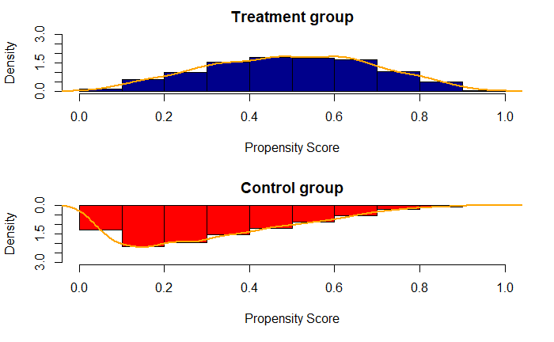

```r
hist(gotNoTreatment, main='Control group', xlab='Propensity Score', ylim=c(3,0), col='red',
     prob = TRUE)   #shows density instead of frequency
lines(density(gotNoTreatment),
      lwd = 2,
      col = "orange")
```

```r
# => What do you think about the overlap?
print("This overlap is almost everywhere. Although there is little overlap on the high propensity score, the positivity assumption is still reasonable because control group always have a chance of getting treatment.")
```

```
[1] "This overlap is almost everywhere. Although there is little overlap on the high propensity score, the positivity assumption is still reasonable because control group always have a chance of getting treatment."
```

```r
print("===================================================")
```

```
[1] "==================================================="
```

We want to do greedy matching on PS using Match with a caliper. Note that instead of the probability PS itself, we usually use the log odds (logit) of PS which is log(PS/(1-PS)) which is also equal to log(PS)-log(1-PS) . So let us first write a function (of one line) to calculate the logit.

```r
print("===================================================")
```

```
[1] "==================================================="
```

```r
# => Complete this function to calculate the log odds
logit <- function(p) {
  return(log(p/(1-p)))
  }
print("===================================================")
```

```
[1] "==================================================="
```

# Now it is time to check the positivity assumption

```r
print("===================================================")
```

```
[1] "==================================================="
```

```r
# => Check the overlap between the propensity scores for the two groups.
logitTreatment <- logit(gotTreatment)
logitNoTreatment <- logit(gotNoTreatment)

#frequency hist
# par(mfrow=c(2,1))
# hist(logitTreatment, main='Group with treatment', xlab='Log-odds of Propensity Score', xlim=c(-5,5), ylim=c(0,650), col='darkblue')
# hist(logitNoTreatment, main='Group without treatment', xlab='Log-odds of Propensity Score', xlim=c(-5,5),ylim=c(650,0), col='red')

#density hist
par(mfrow=c(2,1))
hist(logitTreatment, main='Treatment group', xlab='Log-odds of Propensity Score', xlim=c(-5,5), ylim=c(0,0.6), col='darkblue',
     prob = TRUE)   #shows density instead of frequency
lines(density(logitTreatment),
      lwd = 2,
      col = "orange")
```

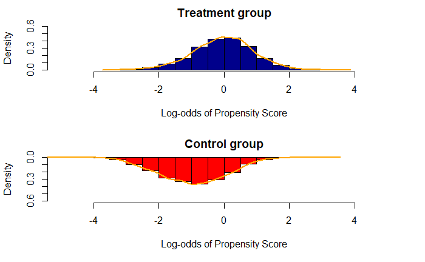

```r
hist(logitNoTreatment, main='Control group', xlab='Log-odds of Propensity Score', xlim=c(-5,5),ylim=c(0.6,0), col='red',
     prob = TRUE)   #shows density instead of frequency
lines(density(logitNoTreatment),
      lwd = 2,
      col = "orange")
```

```r
#What do you think about the overlap?
print("There is better overlap compared to the previous plot, therefore the positivity assumption is still reasonable.")
```

```
[1] "There is better overlap compared to the previous plot, therefore the positivity assumption is still reasonable."
```

```r
print("===================================================")
```

```
[1] "==================================================="
```

Now we want to use Match() with rhc.selected$treatment.swang as treatement, with 1 matched control per treated subject, with X as the logit(pscore), with no replacement and with a caliper of 0.2

```r
print("===================================================")
```

```
[1] "==================================================="
```

```r
# => complete the command

psmatch <- Match(Tr=rhc.selected$treatment.swang, M=1, X=logit(pscore), replace=FALSE, caliper = .2)
matched <- rhc.selected[unlist(psmatch[c("index.treated","index.control")]), ]
print("===================================================")
```

```
[1] "==================================================="
```

## Get standardized differences. Note: xvars is the same as in the first assignment.

```r
print("===================================================")
```

```
[1] "==================================================="
```

```r
# => Complete the command
print(xvars)
```

```
 [1] "ARF"             "CHF"             "Cirrhosis"       "Coma"            "Lung_Cancer"     "MOSF_Malignancy"
 [7] "cardiohx"        "chfhx"           "dementhx"        "psychhx"         "chrpulhx"        "renalhx"
[13] "liverhx"         "malighx"         "immunhx"         "transhx"         "age"             "edu"
[19] "das2d3pc"        "aps1"            "scoma1"          "meanbp1"         "wblc1"           "temp1"
[25] "alb1"            "hema1"           "bili1"           "crea1"           "pot1"            "paco21"
[31] "ph1"             "wtkilo1"         "dnr1"            "resp"            "card"            "gastr"
[37] "renal"           "hema"            "seps"            "trauma"
```

```r
matchedtab1 <- CreateTableOne(vars=xvars, strata = "treatment.swang", data=matched, test = FALSE)
# => print the matching table showing the SMD
print(matchedtab1, smd = TRUE)
```

```
                             Stratified by treatment.swang
                              0             1             SMD
  n                            1733          1733
  ARF (mean (SD))              0.45 (0.50)   0.44 (0.50)   0.034
  CHF (mean (SD))              0.10 (0.30)   0.10 (0.30)   0.012
  Cirrhosis (mean (SD))        0.03 (0.16)   0.03 (0.16)   0.011
  Coma (mean (SD))             0.05 (0.21)   0.05 (0.21)  <0.001
  Lung_Cancer (mean (SD))      0.00 (0.06)   0.00 (0.05)   0.010
  MOSF_Malignancy (mean (SD))  0.08 (0.27)   0.08 (0.27)   0.004
  cardiohx (mean (SD))         0.20 (0.40)   0.20 (0.40)   0.014
  chfhx (mean (SD))            0.20 (0.40)   0.20 (0.40)   0.001
  dementhx (mean (SD))         0.08 (0.26)   0.07 (0.26)   0.007
  psychhx (mean (SD))          0.05 (0.22)   0.05 (0.22)   0.005
  chrpulhx (mean (SD))         0.16 (0.37)   0.16 (0.36)   0.010
  renalhx (mean (SD))          0.05 (0.23)   0.05 (0.22)   0.021
  liverhx (mean (SD))          0.06 (0.24)   0.06 (0.25)   0.012
  malighx (mean (SD))          0.23 (0.42)   0.22 (0.41)   0.021
  immunhx (mean (SD))          0.30 (0.46)   0.29 (0.45)   0.024
  transhx (mean (SD))          0.12 (0.33)   0.13 (0.34)   0.026
  age (mean (SD))             60.87 (17.35) 60.85 (15.63)  0.001
  edu (mean (SD))             11.85 (3.16)  11.77 (3.18)   0.024
  das2d3pc (mean (SD))        20.69 (5.71)  20.66 (5.04)   0.005
  aps1 (mean (SD))            57.44 (19.19) 57.38 (19.23)  0.003
  scoma1 (mean (SD))          18.95 (29.06) 18.63 (27.91)  0.011
  meanbp1 (mean (SD))         72.02 (34.67) 72.84 (35.41)  0.024
  wblc1 (mean (SD))           16.02 (13.11) 15.83 (12.52)  0.015
  temp1 (mean (SD))           37.68 (1.89)  37.63 (1.75)   0.027
  alb1 (mean (SD))             3.03 (0.71)   3.03 (0.95)   0.003
  hema1 (mean (SD))           30.62 (8.10)  30.89 (7.51)   0.035
  bili1 (mean (SD))            2.46 (5.30)   2.49 (4.99)   0.007
  crea1 (mean (SD))            2.30 (2.33)   2.32 (2.00)   0.009
  pot1 (mean (SD))             4.06 (1.07)   4.05 (1.00)   0.008
  paco21 (mean (SD))          37.29 (11.28) 37.40 (11.26)  0.010
  ph1 (mean (SD))              7.39 (0.11)   7.39 (0.11)   0.014
  wtkilo1 (mean (SD))         70.48 (25.77) 70.83 (27.26)  0.013
  dnr1 (mean (SD))             0.08 (0.28)   0.08 (0.28)   0.008
  resp (mean (SD))             0.33 (0.47)   0.33 (0.47)   0.002
  card (mean (SD))             0.39 (0.49)   0.40 (0.49)   0.008
  gastr (mean (SD))            0.18 (0.38)   0.18 (0.38)   0.005
  renal (mean (SD))            0.06 (0.24)   0.06 (0.24)   0.005
  hema (mean (SD))             0.06 (0.24)   0.06 (0.24)   0.007
  seps (mean (SD))             0.21 (0.41)   0.21 (0.41)   0.008
  trauma (mean (SD))           0.01 (0.10)   0.01 (0.11)   0.011
```

```r
# => Are there any variables with bad balance now?
addmargins(table(ExtractSmd(matchedtab1) > 0.2))
```

```
FALSE   Sum
   40    40
```

```r
print("Now there aren't any variables with bad balance.")
```

```
[1] "Now there aren't any variables with bad balance."
```

```r
print("===================================================")
```

```
[1] "==================================================="
```